# Dataset to explore: Ford GoBike System Data

#### Data Source: https://www.lyft.com/bikes/bay-wheels/system-data

### Loading Data

```python
from requests import get
from os import path, getcwd, makedirs, listdir
from io import BytesIO
from zipfile import ZipFile
import pandas as pd
import numpy as np
import matplotlib
from matplotlib import pyplot as plt
import matplotlib.ticker as tick
import matplotlib.dates as mdates
import seaborn as sns
from datetime import datetime
import math
import calendar
import warnings
import os
import glob
import geopy.distance

warnings.filterwarnings('ignore')
from IPython.display import Image
%matplotlib inline
```

```python
# # Create a dir to store data
directory_name = 'RawData'
# makedirs(directory_name)

# for year in range(2018,2020):
#     for month in range(1,13):

#         year = str(year)
#         month = str(month).zfill(2)

#         # Stop in 07/2019
#         if year == '2019' and month == '08':
#             break

#         try:
#             if int(year)==2019 and int(month)>=5:
#                 url = "https://s3.amazonaws.com/baywheels-data/{year}{month}-baywheels-tripdata.csv.zip".format(year=year,month=month)
#             else:
#                 url = "https://s3.amazonaws.com/fordgobike-data/{year}{month}-fordgobike-tripdata.csv.zip".format(year=year,month=month)
#             response = get(url)

#             unzipping_file = ZipFile(BytesIO(response.content))
#             unzipping_file.extractall(directory_name)

#         except:
#             print('Something went wrong, check this url: {url}'.format(url=url))
```

```python
csv_path = os.path.join(os.getcwd(),directory_name,"*.csv")
df = pd.concat([pd.read_csv(f) for f in glob.glob(csv_path)], ignore_index = True)
```

```python
# Have a look
df.sample(10)
```

|  | Unnamed: 16 | bike_id | bike_share_for_all_trip | duration_sec | end_station_id | end_station_latitude | end_station_longitude | end_station_name | end_time | member_birth_year | member_gender | rental_access_method | start_station_id | start_station_latitude | start_station_longitude | start_station_name | start_time | user_type |
| --- | --- | --- | --- | --- | --- | --- | --- | --- | --- | --- | --- | --- | --- | --- | --- | --- | --- | --- |
| 1641969 | NaN | 1358 | No | 720 | 137.0 | 37.750506 | -122.433950 | Jersey St at Castro St | 2018-11-17 18:23:36.8250 | 1991.0 | Female | NaN | 132.0 | 37.751819 | -122.426614 | 24th St at Chattanooga St | 2018-11-17 18:11:36.4350 | Subscriber |
| 783593 | NaN | 393 | No | 256 | 109.0 | 37.763316 | -122.421904 | 17th St at Valencia St | 2018-06-06 16:13:39.4720 | 1985.0 | Female | NaN | 110.0 | 37.763708 | -122.415204 | 17th & Folsom Street Park (17th St at Folsom St) | 2018-06-06 16:09:22.6850 | Subscriber |
| 3094704 | NaN | 608 | No | 862 | 49.0 | 37.780760 | -122.394989 | S Park St at 3rd St | 2019-06-03 10:38:19.1880 | 1995.0 | Male | NaN | 77.0 | 37.773507 | -122.416040 | 11th St at Natoma St | 2019-06-03 10:23:56.1910 | Subscriber |
| 956592 | NaN | 2131 | No | 465 | 16.0 | 37.794130 | -122.394430 | Steuart St at Market St | 2018-07-11 12:34:25.9530 | 1962.0 | Female | NaN | 27.0 | 37.788059 | -122.391865 | Beale St at Harrison St | 2018-07-11 12:26:40.0420 | Subscriber |
| 251192 | NaN | 2180 | No | 4032 | 148.0 | 37.829705 | -122.287610 | Horton St at 40th St | 2018-03-19 16:50:42.5660 | 1993.0 | Female | NaN | 148.0 | 37.829705 | -122.287610 | Horton St at 40th St | 2018-03-19 15:43:30.4100 | Customer |
| 1611836 | NaN | 4317 | No | 422 | 22.0 | 37.789756 | -122.394643 | Howard St at Beale St | 2018-11-28 09:33:22.1220 | 1982.0 | Male | NaN | 66.0 | 37.778742 | -122.392741 | 3rd St at Townsend St | 2018-11-28 09:26:19.8650 | Subscriber |
| 1993792 | NaN | 5313 | No | 449 | 98.0 | 37.765052 | -122.421866 | Valencia St at 16th St | 2019-01-12 18:14:10.6180 | 1997.0 | Male | NaN | 56.0 | 37.773414 | -122.427317 | Koshland Park | 2019-01-12 18:06:41.1470 | Subscriber |
| 1609179 | NaN | 293 | No | 723 | 120.0 | 37.761420 | -122.426435 | Mission Dolores Park | 2018-11-28 18:26:15.8220 | 1987.0 | Male | NaN | 58.0 | 37.776619 | -122.417385 | Market St at 10th St | 2018-11-28 18:14:12.0400 | Subscriber |
| 1734913 | NaN | 1334 | No | 649 | 77.0 | 37.773507 | -122.416040 | 11th St at Natoma St | 2018-12-31 09:46:44.6100 | 1983.0 | Male | NaN | 91.0 | 37.771762 | -122.398438 | Berry St at King St | 2018-12-31 09:35:55.0130 | Subscriber |
| 1300808 | NaN | 1082 | No | 1125 | 89.0 | 37.769218 | -122.407646 | Division St at Potrero Ave | 2018-09-17 09:19:31.1420 | 1986.0 | Male | NaN | 61.0 | 37.776513 | -122.411306 | Howard St at 8th St | 2018-09-17 09:00:45.3290 | Customer |

```python
# It contains a weird column "Unnamed: 16", should drop it.
df.drop(['Unnamed: 16'], axis=1, inplace=True)
df.sample(10)
```

|  | bike_id | bike_share_for_all_trip | duration_sec | end_station_id | end_station_latitude | end_station_longitude | end_station_name | end_time | member_birth_year | member_gender | rental_access_method | start_station_id | start_station_latitude | start_station_longitude | start_station_name | start_time | user_type |
| --- | --- | --- | --- | --- | --- | --- | --- | --- | --- | --- | --- | --- | --- | --- | --- | --- | --- |
| 2919224 | 2401 | No | 1176 | 131.0 | 37.755000 | -122.425728 | 22nd St at Dolores St | 2019-06-30 13:36:27.0950 | 1994.0 | Male | NaN | 350.0 | 37.771431 | -122.405787 | 8th St at Brannan St | 2019-06-30 13:16:50.5330 | Customer |
| 232186 | 2612 | No | 452 | 112.0 | 37.763847 | -122.413004 | Harrison St at 17th St | 2018-03-24 19:21:07.5400 | 1991.0 | Male | NaN | 144.0 | 37.747300 | -122.411403 | Precita Park | 2018-03-24 19:13:35.3920 | Subscriber |
| 3221980 | 3249 | No | 351 | 5.0 | 37.783899 | -122.408445 | Powell St BART Station (Market St at 5th St) | 2019-07-11 08:51:43.8820 | 1992.0 | Male | NaN | 59.0 | 37.774814 | -122.418954 | S Van Ness Ave at Market St | 2019-07-11 08:45:52.3290 | Subscriber |
| 2391866 | 5001 | No | 331 | 121.0 | 37.759210 | -122.421339 | Mission Playground | 2019-03-14 15:08:57.1460 | 1990.0 | Male | NaN | 108.0 | 37.764710 | -122.419957 | 16th St Mission BART | 2019-03-14 15:03:25.6830 | Subscriber |
| 2088049 | 5970 | No | 433 | 36.0 | 37.783830 | -122.398870 | Folsom St at 3rd St | 2019-02-24 14:59:01.9760 | 1992.0 | Male | NaN | 93.0 | 37.770407 | -122.391198 | 4th St at Mission Bay Blvd S | 2019-02-24 14:51:48.5220 | Customer |
| 3025024 | 1182 | No | 285 | 27.0 | 37.788059 | -122.391865 | Beale St at Harrison St | 2019-06-13 09:49:02.8650 | 1989.0 | Male | NaN | 17.0 | 37.792251 | -122.397086 | Embarcadero BART Station (Beale St at Market St) | 2019-06-13 09:44:17.3600 | Subscriber |
| 1303884 | 3675 | No | 485 | 144.0 | 37.747300 | -122.411403 | Precita Park | 2018-09-16 16:48:28.2970 | 1970.0 | Female | NaN | 134.0 | 37.752428 | -122.420628 | Valencia St at 24th St | 2018-09-16 16:40:23.0610 | Subscriber |
| 1103888 | 2350 | No | 322 | 188.0 | 37.842630 | -122.267738 | Dover St at 57th St | 2018-08-17 17:49:40.7860 | 1976.0 | Male | NaN | 241.0 | 37.852477 | -122.270213 | Ashby BART Station | 2018-08-17 17:44:18.2870 | Subscriber |
| 1221072 | 3534 | No | 394 | 175.0 | 37.835946 | -122.262366 | 49th St at Telegraph Ave | 2018-09-28 17:56:49.2790 | 1980.0 | Female | NaN | 176.0 | 37.828410 | -122.266315 | MacArthur BART Station | 2018-09-28 17:50:14.5820 | Subscriber |
| 2327146 | 6306 | No | 494 | 81.0 | 37.775880 | -122.393170 | Berry St at 4th St | 2019-03-21 09:45:59.8930 | 1990.0 | Male | NaN | 126.0 | 37.761634 | -122.390648 | Esprit Park | 2019-03-21 09:37:45.4770 | Subscriber |

```python
# Check the Gender
df.groupby('member_gender')['member_gender'].count()
```

```
member_gender
?            2589
F            5076
Female     752922
M           19885
Male      2266085
O             456
Other       51687
Name: member_gender, dtype: int64
```

```python
# Handle the Gender error
def gender_wrangle(gender):
    if gender == 'F':
        gender = 'Female'
    elif gender == 'M':
        gender = 'Male'
    elif gender == 'O':
        gender = 'Other'
    elif gender == '?':
        gender = 'Unknown'
    return gender

df['member_gender'] = df['member_gender'].apply(lambda x: gender_wrangle(x))
```

```python
# Check the Gender again
df.groupby('member_gender')['member_gender'].count()
```

```
member_gender
Female      757998
Male       2285970
Other        52143
Unknown       2589
Name: member_gender, dtype: int64
```

```python
# Check the duration distribution
df['duration_sec'].describe()
```

```
count    3.308432e+06
mean     8.295888e+02
std      2.175275e+03
min      6.000000e+01
25%      3.490000e+02
50%      5.550000e+02
75%      8.690000e+02
max      8.636600e+04
Name: duration_sec, dtype: float64
```

```python
# Check data types
df.info()
```

```
<class 'pandas.core.frame.DataFrame'>
RangeIndex: 3308432 entries, 0 to 3308431
Data columns (total 17 columns):
bike_id                    int64
bike_share_for_all_trip    object
duration_sec               int64
end_station_id             float64
end_station_latitude       float64
end_station_longitude      float64
end_station_name           object
end_time                   object
member_birth_year          float64
member_gender              object
rental_access_method       object
start_station_id           float64
start_station_latitude     float64
start_station_longitude    float64
start_station_name         object
start_time                 object
user_type                  object
dtypes: float64(7), int64(2), object(8)
memory usage: 429.1+ MB
```

```python
# Handle the data types
df['bike_id'] = df['bike_id'].astype(str)
df['start_time']=pd.to_datetime(df.start_time)
df['end_time']=pd.to_datetime(df.end_time)
df['start_station_id'] = df['start_station_id'].astype(str)
df['end_station_id'] = df['end_station_id'].astype(str)
df['start_station_name'] = df['start_station_name'].astype(str)
df['end_station_name'] = df['end_station_name'].astype(str)
df.info()
```

```
<class 'pandas.core.frame.DataFrame'>
RangeIndex: 3308432 entries, 0 to 3308431
Data columns (total 17 columns):
bike_id                    object
bike_share_for_all_trip    object
duration_sec               int64
end_station_id             object
end_station_latitude       float64
end_station_longitude      float64
end_station_name           object
end_time                   datetime64[ns]
member_birth_year          float64
member_gender              object
rental_access_method       object
start_station_id           object
start_station_latitude     float64
start_station_longitude    float64
start_station_name         object
start_time                 datetime64[ns]
user_type                  object
dtypes: datetime64[ns](2), float64(5), int64(1), object(9)
memory usage: 429.1+ MB
```

```python
# Check null values
df.isna().sum()
```

```
bike_id                          0
bike_share_for_all_trip      33517
duration_sec                     0
end_station_id                   0
end_station_latitude             0
end_station_longitude            0
end_station_name                 0
end_time                         0
member_birth_year           212684
member_gender               209732
rental_access_method       3304539
start_station_id                 0
start_station_latitude           0
start_station_longitude          0
start_station_name               0
start_time                       0
user_type                        0
dtype: int64
```

```python
# Check duplicated values
df.duplicated().sum()
```

```
0
```

```python
# Check how many records
df.shape[0]
```

```
3308432
```

```python
# Check how many data fields
df.shape[1]
```

```
17
```

### Set up new columns

```python
df['Age'] = int(datetime.now().year) - df['member_birth_year']
df['start_time_month'] = df['start_time'].dt.strftime('%b')
df['start_time_day']=df['start_time'].dt.strftime('%A')
df['start_time_hour'] = df['start_time'].dt.hour
df['end_time_hour'] = df['end_time'].dt.hour
df['duration_min'] = (df['duration_sec']/60).astype(float)
```

### Calculate moving distance

```python
def calculate_distance(x_start, y_start, x_end, y_end):
    """
    To calculate distance using coorindates.
    """
    coords_1 = (x_start, y_start)
    coords_2 = (x_end, y_end)

    return geopy.distance.vincenty(coords_1, coords_2).km
```

```python
df['distance_km'] = df.apply(lambda x: calculate_distance(x['start_station_latitude'], x['start_station_longitude'],
                                                           x['end_station_latitude'], x['end_station_longitude']), axis=1)
```

### Address outliers

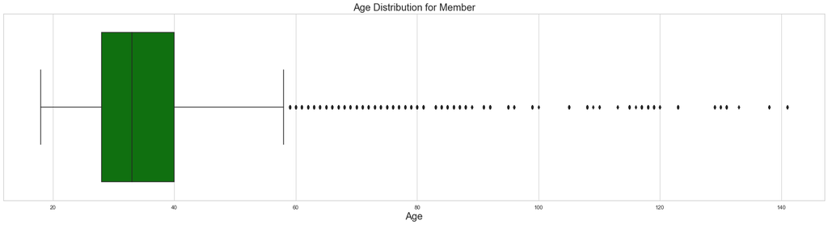

```python
# Age distribution
sns.set(style="whitegrid", font_scale=1.00, rc={'figure.figsize':(30,7)})
ax = sns.boxplot(x=df["Age"], color='green')
ax.set_xlabel('Age', fontsize=20)
ax.set_title("Age Distribution for Member", fontsize=20);
```

Surprisely, the data contains age with more than 100 years, even 140 years. Maybe those are fake data. From the box plot, seems treating the age greater than 58 years as outliers is reasonable.

```python
df.drop(df[df.Age > 58].index, inplace=True)
```

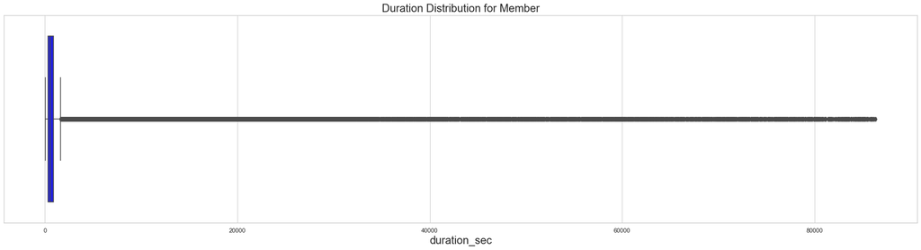

```python
# Duration distribution
sns.set(style="whitegrid", font_scale=1.00, rc={'figure.figsize':(30,7)})
ax = sns.boxplot(x=df["duration_sec"], color='blue')
ax.set_xlabel('duration_sec', fontsize=20)
ax.set_title("Duration Distribution for Member", fontsize=20);
```

Need to remove some unreasonble time duration.

```python
df.drop(df[df.duration_sec > 3600].index, inplace=True)
```

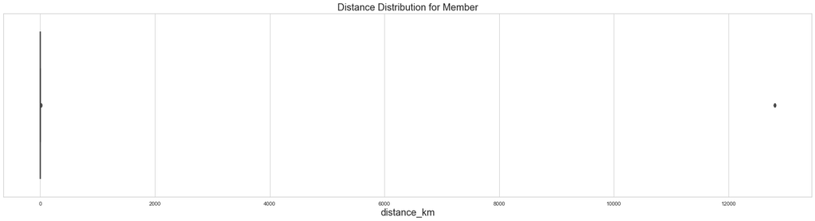

```python
# Duration distribution
sns.set(style="whitegrid", font_scale=1.00, rc={'figure.figsize':(30,7)})
ax = sns.boxplot(x=df["distance_km"], color='blue')
ax.set_xlabel('distance_km', fontsize=20)
ax.set_title("Distance Distribution for Member", fontsize=20);
```

Need to remove some unreasonble distance.

```python
df.drop(df[df.distance_km > 70].index, inplace=True)
```

```python
# Recheck the distribution
df.Age.describe().apply(lambda x: format(x, 'f'))
```

```
count    2964996.000000
mean          34.193202
std            8.782359
min           18.000000
25%           28.000000
50%           32.000000
75%           39.000000
max           58.000000
Name: Age, dtype: object
```

```python
df.duration_sec.describe()
```

```
count    3.159785e+06
mean     6.718578e+02
std      4.819949e+02
min      6.000000e+01
25%      3.460000e+02
50%      5.480000e+02
75%      8.480000e+02
max      3.600000e+03
Name: duration_sec, dtype: float64
```

```python
df.distance_km.describe()
```

```
count    3.159785e+06
mean     1.641479e+00
std      1.047407e+00
min      0.000000e+00
25%      8.977501e-01
50%      1.406893e+00
75%      2.149547e+00
max      1.655451e+01
Name: distance_km, dtype: float64
```

### Save Data

```python
df.to_excel('Gobike_dataset.xlsx', index=None)
```

## Univariate Exploration

### Number of Bike Rides Over Time

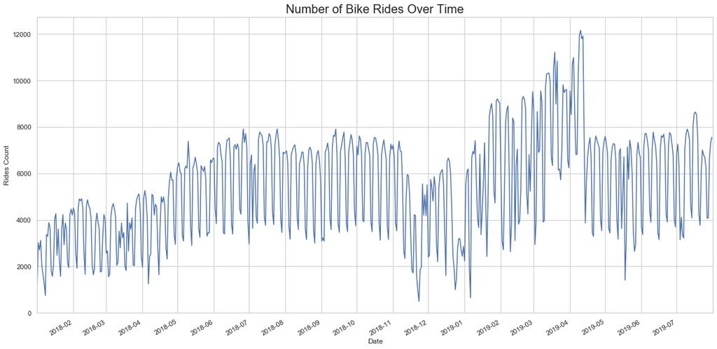

```python
df.groupby(df['start_time'].dt.date).size().plot(figsize=(20,10))
ax = plt.gca()
ax.set_ylabel('Rides Count')
ax.set_xlabel('Date')
ax.set_xlim([df.start_time.min(), df.start_time.max()])
ax.xaxis.set_major_locator(mdates.MonthLocator(interval=1)) # Show x-axis as month by month (monthly)
ax.set_ylim(0)
ax.set_title("Number of Bike Rides Over Time", fontsize=20);
plt.gcf().autofmt_xdate()
```

From the Gobike rides count trend plot, seems there is some seasonality.

### The Monthly Usage of Bike

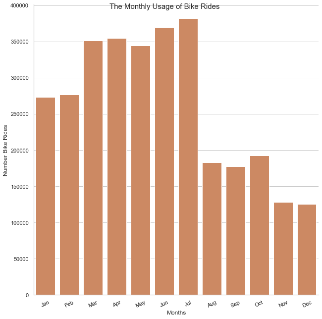

```python
base_color = sns.color_palette()[1]
lm  = sns.catplot(data=df, x='start_time_month', kind='count', color = base_color, height = 9)
lm.set_axis_labels("Months", "Number Bike Rides")
lm.set_xticklabels(rotation=25)
lm.fig.suptitle('The Monthly Usage of Bike Rides', fontsize=15);
```

User tends to take more rides at Jan. to Jul. but less rides at Aug. to Dec.

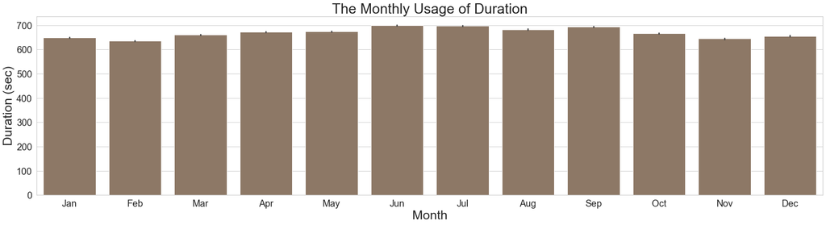

```python
base_color = sns.color_palette()[5]
ax = sns.barplot(data=df, x='start_time_month', y='duration_sec', color = base_color)
ax.set_title('The Monthly Usage of Duration', fontsize=30)
ax.set_xlabel('Month', fontsize=27)
ax.set_ylabel('Duration (sec)', fontsize=27)
ax.tick_params(labelsize=20);
```

The average time duration is comparable for each month, no month dependency.

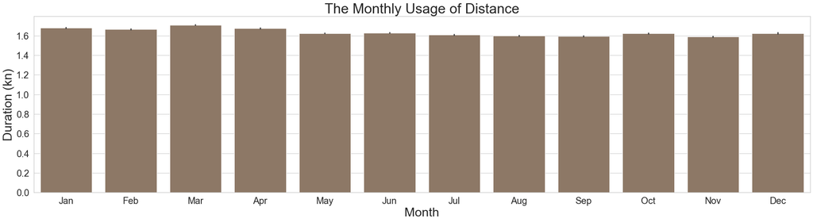

```python
base_color = sns.color_palette()[5]
ax = sns.barplot(data=df, x='start_time_month', y='distance_km', color = base_color)
ax.set_title('The Monthly Usage of Distance', fontsize=30)
ax.set_xlabel('Month', fontsize=27)
ax.set_ylabel('Duration (kn)', fontsize=27)
ax.tick_params(labelsize=20);
```

The average travel distance is comparable for each month.

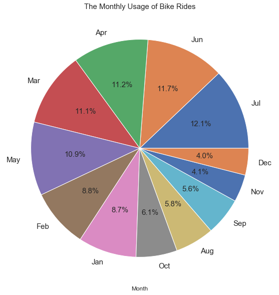

```python
df.start_time_month.value_counts().plot(kind='pie', figsize=(10,10), fontsize =15, autopct='%1.1f%%')

ax = plt.gca()
ax.set_ylabel('')
ax.set_xlabel('Month')
ax.set_title("The Monthly Usage of Bike Rides", fontsize=15);
```

confirm "The Monthly Usage of Bike Rides" bar plot.

### The Daily Usage of Bike

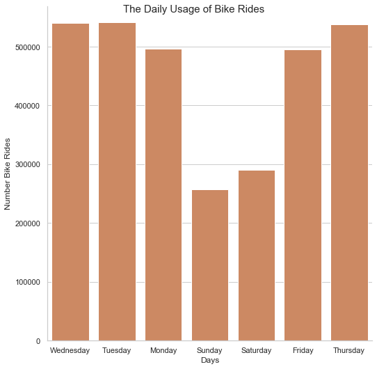

```python
base_color = sns.color_palette()[1]
lm  = sns.catplot(data=df, x='start_time_day', kind='count', color = base_color, height = 7.5)
lm.set_axis_labels("Days", "Number Bike Rides")

lm.fig.suptitle('The Daily Usage of Bike Rides', fontsize=15);
```

The number of bike rides is reduced at Saturday and Sunday.

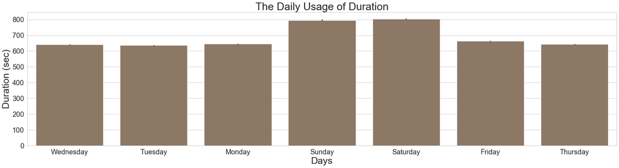

```python
base_color = sns.color_palette()[5]
ax = sns.barplot(data=df, x='start_time_day', y='duration_sec', color = base_color)
ax.set_title('The Daily Usage of Duration', fontsize=30)
ax.set_xlabel('Days', fontsize=27)
ax.set_ylabel('Duration (sec)', fontsize=27)
ax.tick_params(labelsize=20);
```

User tends to take more time on riding Gobike during holidays.

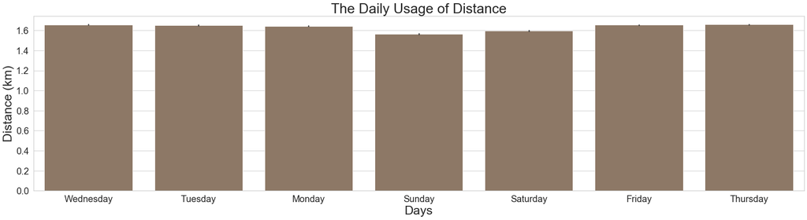

```python
base_color = sns.color_palette()[5]
ax = sns.barplot(data=df, x='start_time_day', y='distance_km', color = base_color)
ax.set_title('The Daily Usage of Distance', fontsize=30)
ax.set_xlabel('Days', fontsize=27)
ax.set_ylabel('Distance (km)', fontsize=27)
ax.tick_params(labelsize=20);
```

The daily traveling distance seems not varies with week days.

### Percentage of Bike Rides for Members Gender

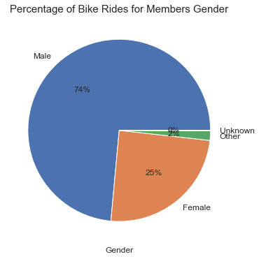

```python
df.member_gender.value_counts().plot(kind='pie', figsize=(6,6),fontsize=12, autopct='%1.0f%%')
ax = plt.gca()
ax.set_ylabel('')
ax.set_xlabel('Gender')
ax.set_title("Percentage of Bike Rides for Members Gender", fontsize=15);
```

Most of users are male.

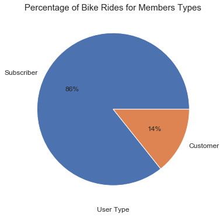

```python
df.user_type.value_counts().plot(kind='pie', figsize=(6,6),fontsize=12, autopct='%1.0f%%')
ax = plt.gca()
ax.set_ylabel('')
ax.set_xlabel('User Type')
ax.set_title("Percentage of Bike Rides for Members Types", fontsize=15);
```

## Bivariate Exploration

### The Monthly Usage of Bike Per Gender

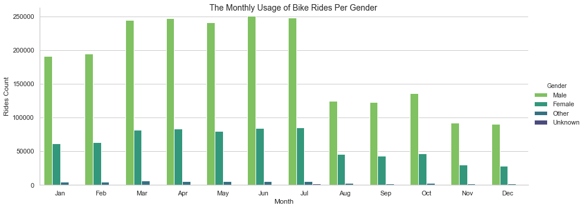

```python
lm = sns.catplot(data=df, x='start_time_month', hue='member_gender', kind='count',aspect=20/8, color=base_color,palette='viridis_r')

lm.set_axis_labels('Month', 'Rides Count')
lm._legend.set_title('Gender')
lm.fig.suptitle('The Monthly Usage of Bike Rides Per Gender', fontsize=14);
```

Both male and female users present similar trend of ride counts.

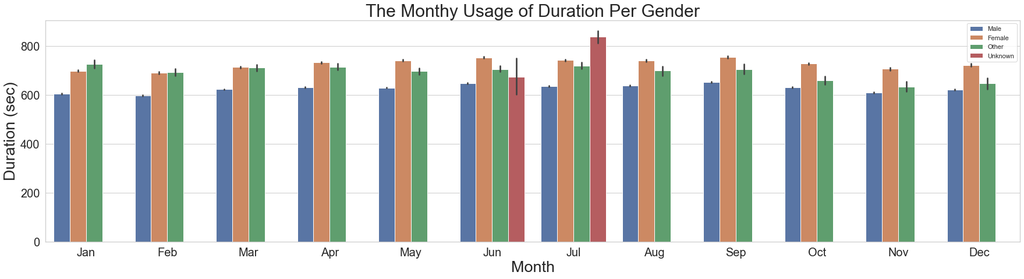

```python
ax = sns.barplot(data=df, x='start_time_month', y='duration_sec', hue='member_gender')
ax.set_title('The Monthy Usage of Duration Per Gender', fontsize=30)
ax.set_xlabel('Month', fontsize=27)
ax.set_ylabel('Duration (sec)', fontsize=27)
ax.tick_params(labelsize=20)
ax.legend(title_fontsize=20);
```

Both male and female users present similar trend of ride duration, but other/unknown varies. However, the number of other/unknown gender users is relative small.

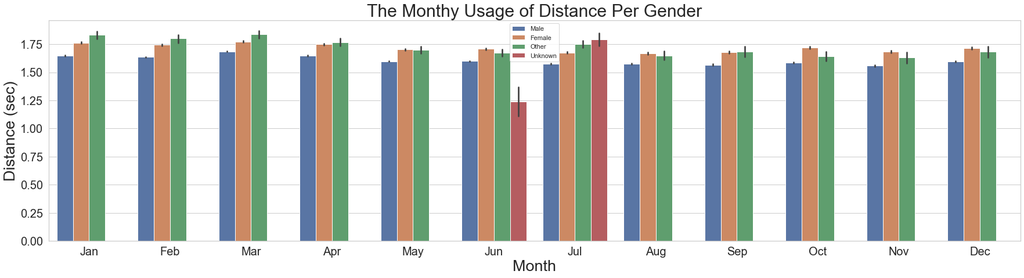

```python
ax = sns.barplot(data=df, x='start_time_month', y='distance_km', hue='member_gender')
ax.set_title('The Monthy Usage of Distance Per Gender', fontsize=30)
ax.set_xlabel('Month', fontsize=27)
ax.set_ylabel('Distance (sec)', fontsize=27)
ax.tick_params(labelsize=20)
ax.legend(title_fontsize=20);
```

### The Monthly Usage of Bike Rides Gender Based on User Type

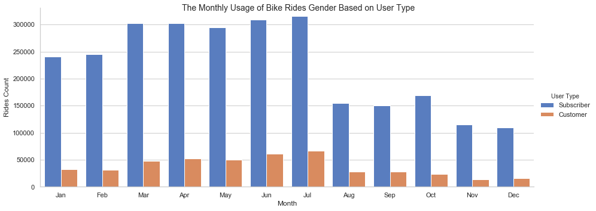

```python
lm = sns.catplot(data=df, x='start_time_month', hue='user_type', kind='count',aspect=20/8, color=base_color,palette='muted')

lm.set_axis_labels('Month', 'Rides Count')
lm._legend.set_title('User Type')
lm.fig.suptitle('The Monthly Usage of Bike Rides Gender Based on User Type', fontsize=14);
```

The two user types follow a similar trend of bike ride counts.

### The Daily Usage of Bike Rides Per Gender

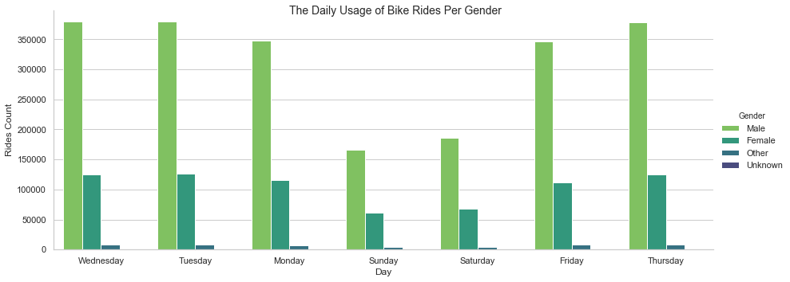

```python
lm = sns.catplot(data=df, x='start_time_day', hue='member_gender', kind='count',aspect=20/8, color=base_color,palette='viridis_r')

lm.set_axis_labels('Day', 'Rides Count')
lm._legend.set_title('Gender')
lm.fig.suptitle('The Daily Usage of Bike Rides Per Gender', fontsize=14);
```

### The Daily Usage of Bike Rides Gender Based on User Type

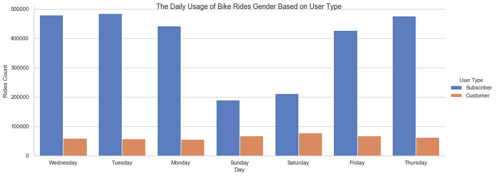

```python
lm = sns.catplot(data=df, x='start_time_day', hue='user_type', kind='count',aspect=20/8, color=base_color,palette='muted')

lm.set_axis_labels('Day', 'Rides Count')
lm._legend.set_title('User Type')
lm.fig.suptitle('The Daily Usage of Bike Rides Gender Based on User Type', fontsize=14);
```

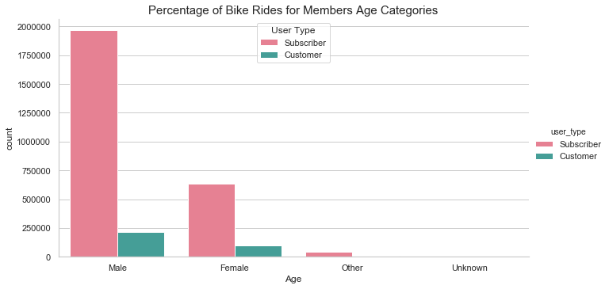

```python
lm = sns.catplot(data=df, x='member_gender', hue='user_type', kind='count',aspect=15/8, color=base_color, palette='husl')

ax = plt.gca()
ax.legend().set_title('User Type')
ax.set_ylabel('count')
ax.set_xlabel('Age')
ax.set_title('Percentage of Bike Rides for Members Age Categories', fontsize=15);
```

The gender percentage of user types seem comparable.

### Age Distribution Based on Gender

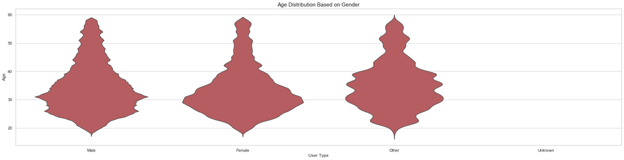

```python
base_color = sns.color_palette()[3]
sns.violinplot(data=df, x='member_gender', y='Age', color=base_color, inner=None, height=12)

ax = plt.gca()
ax.set_ylabel('Age')
ax.set_xlabel('User Type')
ax.set_title('Age Distribution Based on Gender', fontsize=15);
```

Although the violin age distribution plot seems different, age of both male and female concentrates on 25-40 years.

### Age Distribution Based on User Type

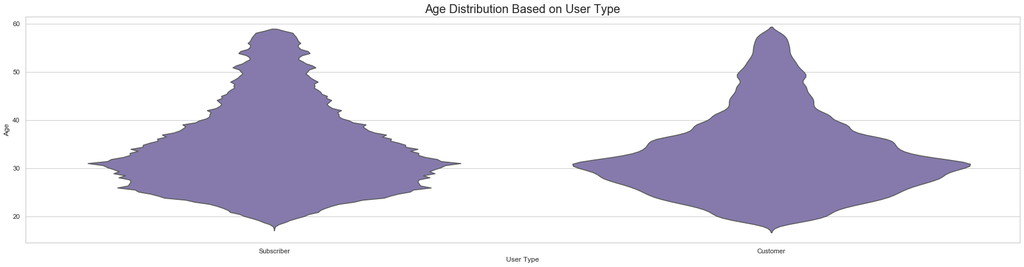

```python
base_color = sns.color_palette()[4]
sns.violinplot(data=df, x='user_type', y='Age', aspect=15/8, color=base_color, inner=None, height=12)

ax = plt.gca()
ax.set_ylabel('Age')
ax.set_xlabel('User Type')
ax.set_title('Age Distribution Based on User Type', fontsize=20);
```

Age of both subscriber and customer concentrates on 25-40 years.

### Duration Distribution Based on User Type

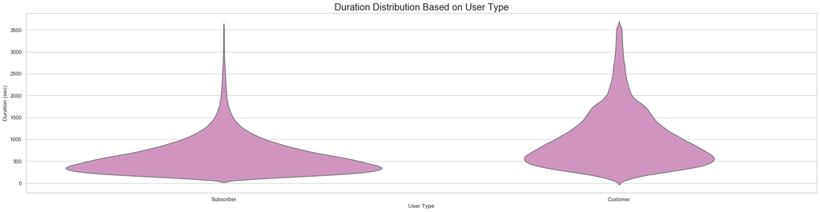

```python
base_color = sns.color_palette()[6]
sns.violinplot(data=df, x='user_type', y='duration_sec', aspect=15/8, color=base_color, inner=None, height=12)

ax = plt.gca()
ax.set_ylabel('Duration (sec)')
ax.set_xlabel('User Type')
ax.set_title('Duration Distribution Based on User Type', fontsize=20);
```

Extreme duration values made it hard to observe the distribution.

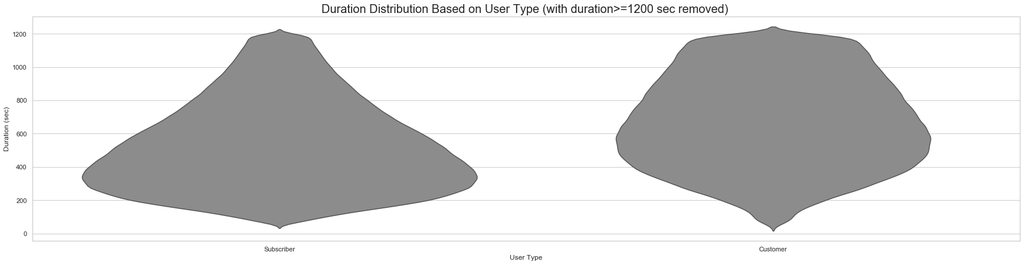

```python
# Remove duration >= 1200
df_temp = df.loc[df.duration_sec<1200]

base_color = sns.color_palette()[7]
sns.violinplot(data=df_temp, x='user_type', y='duration_sec', aspect=15/8, color=base_color, inner=None, height=12)

ax = plt.gca()
ax.set_ylabel('Duration (sec)')
ax.set_xlabel('User Type')
ax.set_title('Duration Distribution Based on User Type (with duration>=1200 sec removed) ', fontsize=20);
```

Let's focus on duration within 1200 sec (20 mins) records, subscribers tend to finish their travel in less time duration.

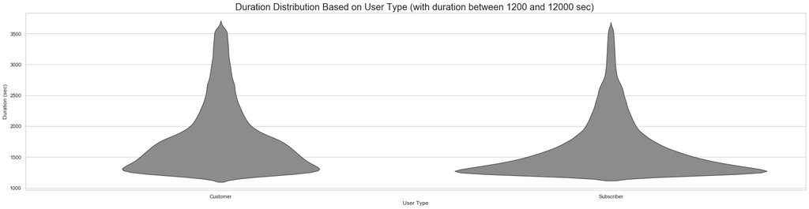

```python
# Duration between 1200 and 12000
df_temp = df.loc[(df.duration_sec>=1200) & (df.duration_sec<12000)]

base_color = sns.color_palette()[7]
sns.violinplot(data=df_temp, x='user_type', y='duration_sec', aspect=15/8, color=base_color, inner=None, height=12)

ax = plt.gca()
ax.set_ylabel('Duration (sec)')
ax.set_xlabel('User Type')
ax.set_title('Duration Distribution Based on User Type (with duration between 1200 and 12000 sec) ', fontsize=20);
```

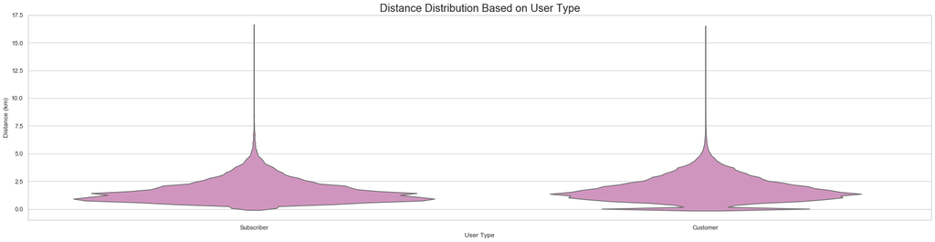

```python
base_color = sns.color_palette()[6]
sns.violinplot(data=df, x='user_type', y='distance_km', aspect=15/8, color=base_color, inner=None, height=12)

ax = plt.gca()
ax.set_ylabel('Distance (km)')
ax.set_xlabel('User Type')
ax.set_title('Distance Distribution Based on User Type', fontsize=20);
```

Extreme distance values made it hard to observe the distribution.

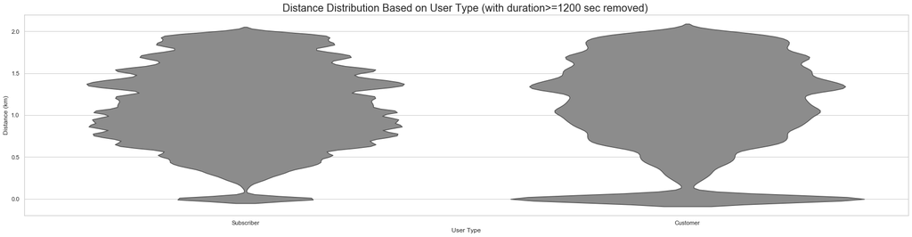

```python
# Remove distance >= 2.0
df_temp = df.loc[df.distance_km<2.0]

base_color = sns.color_palette()[7]
sns.violinplot(data=df_temp, x='user_type', y='distance_km', aspect=15/8, color=base_color, inner=None, height=12)

ax = plt.gca()
ax.set_ylabel('Distance (km)')
ax.set_xlabel('User Type')
ax.set_title('Distance Distribution Based on User Type (with duration>=1200 sec removed) ', fontsize=20);
```

## Multivariate Exploration

### The Monthly Usage of Bike Rides per User Type Based on Gender

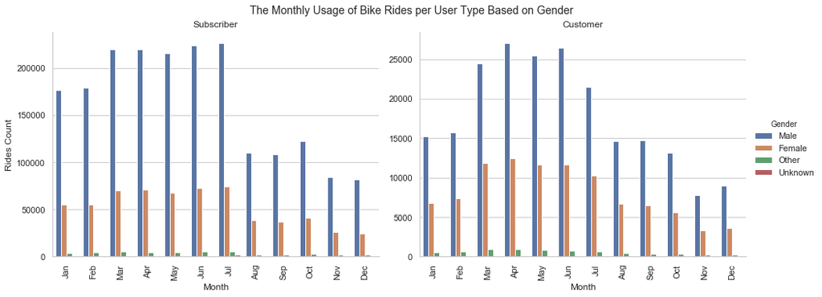

```python
lm = sns.catplot(data=df, x='start_time_month', col="user_type", hue='member_gender', kind='count', aspect=20/15,
                 sharey=False)

lm.set_axis_labels('Month', 'Rides Count')
lm.set_xticklabels(rotation=90)
lm._legend.set_title('Gender')
lm.set_titles('{col_name}')
lm.fig.suptitle('The Monthly Usage of Bike Rides per User Type Based on Gender', fontsize=14, y=1.02);
```

### The Monthy Usage of Duration Per Gender based on User Type

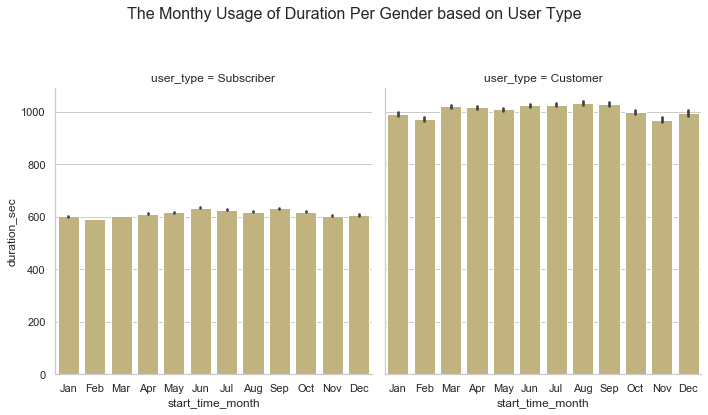

```python
base_color = sns.color_palette()[8]
ax = sns.catplot('start_time_month', 'duration_sec', col='user_type', data=df, kind='bar', color=base_color)
ax.fig.suptitle('The Monthy Usage of Duration Per Gender based on User Type', fontsize=16, y=1.15);
```

Customer type users spend more time riding GoBike, and the month trend fluctuates; whereas subscribers spend almost the same time over months.

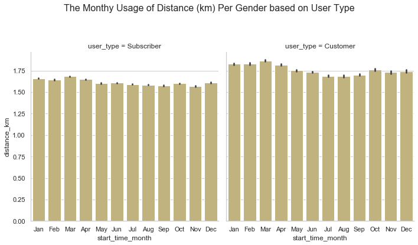

```python
base_color = sns.color_palette()[8]
ax = sns.catplot('start_time_month', 'distance_km', col='user_type', data=df, kind='bar', color=base_color)
ax.fig.suptitle('The Monthy Usage of Distance (km) Per Gender based on User Type', fontsize=16, y=1.15);
```

Both customer and subscriber present the same distance trend.

## Reference

- https://seaborn.pydata.org/generated/seaborn.catplot.html
- https://seaborn.pydata.org/generated/seaborn.barplot.html
- https://stackoverflow.com/questions/43670164/font-size-of-axis-labels-in-seaborn?rq=1
- https://stackoverflow.com/questions/38807895/seaborn-multiple-barplots/38808042